# EasyVisa_Full_Code_Notebook_0_58964200_1769377447

## Problem Statement

### Business Context

Business communities in the United States are facing high demand for human resources, but one of the constant challenges is identifying and attracting the right talent, which is perhaps the most important element in remaining competitive. Companies in the United States look for hard-working, talented, and qualified individuals both locally as well as abroad.

The Immigration and Nationality Act (INA) of the US permits foreign workers to come to the United States to work on either a temporary or permanent basis. The act also protects US workers against adverse impacts on their wages or working conditions by ensuring US employers' compliance with statutory requirements when they hire foreign workers to fill workforce shortages. The immigration programs are administered by the Office of Foreign Labor Certification (OFLC).

OFLC processes job certification applications for employers seeking to bring foreign workers into the United States and grants certifications in those cases where employers can demonstrate that there are not sufficient US workers available to perform the work at wages that meet or exceed the wage paid for the occupation in the area of intended employment.

### Objective

In FY 2016, the OFLC processed 775,979 employer applications for 1,699,957 positions for temporary and permanent labor certifications. This was a nine percent increase in the overall number of processed applications from the previous year. The process of reviewing every case is becoming a tedious task as the number of applicants is increasing every year.

The increasing number of applicants every year calls for a Machine Learning based solution that can help in shortlisting the candidates having higher chances of VISA approval. OFLC has hired the firm EasyVisa for data-driven solutions. You as a data scientist at EasyVisa have to analyze the data provided and, with the help of a classification model:

- Facilitate the process of visa approvals.
- Recommend a suitable profile for the applicants for whom the visa should be certified or denied based on the drivers that significantly influence the case status.

### Data Description

The data contains the different attributes of employee and the employer. The detailed data dictionary is given below.

- case_id: ID of each visa application
- continent: Information of continent the employee
- education_of_employee: Information of education of the employee
- has_job_experience: Does the employee has any job experience? Y= Yes; N = No
- requires_job_training: Does the employee require any job training? Y = Yes; N = No
- no_of_employees: Number of employees in the employer's company
- yr_of_estab: Year in which the employer's company was established
- region_of_employment: Information of foreign worker's intended region of employment in the US.
- prevailing_wage: Average wage paid to similarly employed workers in a specific occupation in the area of intended employment. The purpose of the prevailing wage is to ensure that the foreign worker is not underpaid compared to other workers offering the same or similar service in the same area of employment.
- unit_of_wage: Unit of prevailing wage. Values include Hourly, Weekly, Monthly, and Yearly.
- full_time_position: Is the position of work full-time? Y = Full Time Position; N = Part Time Position
- case_status: Flag indicating if the Visa was certified or denied

## Installing and Importing the necessary libraries

```python
# Installing the libraries with the specified version.
!pip install numpy==2.0.2 pandas==2.2.2 matplotlib==3.10.0 seaborn==0.13.2 scikit-learn==1.6.1 sklearn-pandas==2.2.0 xgboost==2.0.3 -q --user
```

**Note**: *After running the above cell, kindly restart the notebook kernel and run all cells sequentially from the below.*

```python
# Libraries to help with reading and manipulating data
import numpy as np
import pandas as pd

# Library to split data
from sklearn.model_selection import train_test_split

# To oversample and undersample data
from imblearn.over_sampling import SMOTE
from imblearn.under_sampling import RandomUnderSampler
from sklearn.model_selection import train_test_split, StratifiedKFold, cross_val_score


# libaries to help with data visualization
import matplotlib.pyplot as plt
import seaborn as sns

# Removes the limit for the number of displayed columns
pd.set_option("display.max_columns", None)
# Sets the limit for the number of displayed rows
pd.set_option("display.max_rows", 100)


# Libraries different ensemble classifiers
from sklearn.ensemble import (
    BaggingClassifier,
    RandomForestClassifier,
    AdaBoostClassifier,
    GradientBoostingClassifier
)

from xgboost import XGBClassifier
from sklearn.tree import DecisionTreeClassifier
from sklearn.model_selection import train_test_split
from sklearn.model_selection import GridSearchCV, RandomizedSearchCV

# Libraries to get different metric scores
from sklearn import metrics
from sklearn.metrics import (
    confusion_matrix,
    accuracy_score,
    precision_score,
    recall_score,
    f1_score,
)

# To tune different models
from sklearn.model_selection import RandomizedSearchCV

# To ignore unnecessary warnings
import warnings
warnings.filterwarnings("ignore")
```

## Import Dataset

```python
from google.colab import drive
drive.mount('/content/drive')
```

```python
##  Code to read the data from the drive
EasyVisa = pd.read_csv("/content/drive/MyDrive/Notebooks/Bagging_and_Random_Forest/Assignment/EasyVisa.csv")
```

```python
# copying data to another variable to avoid any changes to original data
data = EasyVisa.copy()
```

## Overview of the Dataset

#### View the first and last 5 rows of the dataset

```python
## Code to view top 5 rows of the data
data.head(5)
```

|  | case_id | continent | education_of_employee | has_job_experience | requires_job_training | no_of_employees | yr_of_estab | region_of_employment | prevailing_wage | unit_of_wage | full_time_position | case_status |
| --- | --- | --- | --- | --- | --- | --- | --- | --- | --- | --- | --- | --- |
| 0 | EZYV01 | Asia | High School | N | N | 14513 | 2007 | West | 592.2029 | Hour | Y | Denied |
| 1 | EZYV02 | Asia | Master's | Y | N | 2412 | 2002 | Northeast | 83425.6500 | Year | Y | Certified |
| 2 | EZYV03 | Asia | Bachelor's | N | Y | 44444 | 2008 | West | 122996.8600 | Year | Y | Denied |
| 3 | EZYV04 | Asia | Bachelor's | N | N | 98 | 1897 | West | 83434.0300 | Year | Y | Denied |
| 4 | EZYV05 | Africa | Master's | Y | N | 1082 | 2005 | South | 149907.3900 | Year | Y | Certified |

```python
## Code to view last 5 rows of the data
data.tail(5)
```

|  | case_id | continent | education_of_employee | has_job_experience | requires_job_training | no_of_employees | yr_of_estab | region_of_employment | prevailing_wage | unit_of_wage | full_time_position | case_status |
| --- | --- | --- | --- | --- | --- | --- | --- | --- | --- | --- | --- | --- |
| 25475 | EZYV25476 | Asia | Bachelor's | Y | Y | 2601 | 2008 | South | 77092.57 | Year | Y | Certified |
| 25476 | EZYV25477 | Asia | High School | Y | N | 3274 | 2006 | Northeast | 279174.79 | Year | Y | Certified |
| 25477 | EZYV25478 | Asia | Master's | Y | N | 1121 | 1910 | South | 146298.85 | Year | N | Certified |
| 25478 | EZYV25479 | Asia | Master's | Y | Y | 1918 | 1887 | West | 86154.77 | Year | Y | Certified |
| 25479 | EZYV25480 | Asia | Bachelor's | Y | N | 3195 | 1960 | Midwest | 70876.91 | Year | Y | Certified |

```python
# Code to view 10 random sample rows of the dataset
data.sample(10)
```

|  | case_id | continent | education_of_employee | has_job_experience | requires_job_training | no_of_employees | yr_of_estab | region_of_employment | prevailing_wage | unit_of_wage | full_time_position | case_status |
| --- | --- | --- | --- | --- | --- | --- | --- | --- | --- | --- | --- | --- |
| 19622 | EZYV19623 | North America | Master's | Y | N | 1085 | 2005 | Northeast | 78339.7700 | Year | Y | Certified |
| 20276 | EZYV20277 | Asia | Bachelor's | Y | N | 3700 | 1855 | Midwest | 62766.9400 | Year | Y | Certified |
| 5592 | EZYV5593 | Asia | High School | Y | N | 4274 | 1969 | Midwest | 95579.2700 | Year | Y | Denied |
| 316 | EZYV317 | North America | High School | Y | N | 3550 | 2012 | West | 268.1379 | Hour | Y | Certified |
| 1825 | EZYV1826 | Asia | Master's | N | N | 1684 | 2004 | South | 31438.9900 | Year | Y | Certified |
| 2258 | EZYV2259 | Europe | Master's | N | N | 4921 | 1998 | South | 66295.3400 | Year | N | Certified |
| 1844 | EZYV1845 | Asia | Bachelor's | N | N | 1336 | 1925 | South | 390.1588 | Hour | Y | Certified |
| 11144 | EZYV11145 | Asia | Bachelor's | Y | N | 1604 | 2000 | West | 120687.3700 | Year | Y | Certified |
| 3897 | EZYV3898 | Asia | Bachelor's | Y | N | 470 | 1824 | Northeast | 70729.8500 | Week | Y | Denied |
| 23155 | EZYV23156 | Europe | Doctorate | Y | N | 1688 | 1839 | Northeast | 109348.8800 | Year | Y | Certified |

#### Understand the shape of the dataset

```python
## Understand the shape of the dataset.
data.shape
```

```
(25480, 12)
```

The dataset has 25480 rows and 12 columns

#### Check the data types of the columns for the dataset

```python
## Code to view the datatypes of the data
data.info()
```

```
<class 'pandas.core.frame.DataFrame'>
RangeIndex: 25480 entries, 0 to 25479
Data columns (total 12 columns):
 #   Column                 Non-Null Count  Dtype
---  ------                 --------------  -----
 0   case_id                25480 non-null  object
 1   continent              25480 non-null  object
 2   education_of_employee  25480 non-null  object
 3   has_job_experience     25480 non-null  object
 4   requires_job_training  25480 non-null  object
 5   no_of_employees        25480 non-null  int64
 6   yr_of_estab            25480 non-null  int64
 7   region_of_employment   25480 non-null  object
 8   prevailing_wage        25480 non-null  float64
 9   unit_of_wage           25480 non-null  object
 10  full_time_position     25480 non-null  object
 11  case_status            25480 non-null  object
dtypes: float64(1), int64(2), object(9)
memory usage: 2.3+ MB
```

```python
## Checking the number of unique values in each column
data.nunique();
```

```python
## Check for duplicated values
int(data.duplicated().sum())
```

```
0
```

```python
## Check for Nulls
data.isnull().sum()
```

|  | 0 |
| --- | --- |
| case_id | 0 |
| continent | 0 |
| education_of_employee | 0 |
| has_job_experience | 0 |
| requires_job_training | 0 |
| no_of_employees | 0 |
| yr_of_estab | 0 |
| region_of_employment | 0 |
| prevailing_wage | 0 |
| unit_of_wage | 0 |
| full_time_position | 0 |
| case_status | 0 |

**dtype:** int64

## Exploratory Data Analysis (EDA)

#### Let's check the statistical summary of the data

```python
## Code to print the statistical summary of the data
data.describe(include="all").T
```

|  | count | unique | top | freq | mean | std | min | 25% | 50% | 75% | max |
| --- | --- | --- | --- | --- | --- | --- | --- | --- | --- | --- | --- |
| case_id | 25480 | 25480 | EZYV25480 | 1 | NaN | NaN | NaN | NaN | NaN | NaN | NaN |
| continent | 25480 | 6 | Asia | 16861 | NaN | NaN | NaN | NaN | NaN | NaN | NaN |
| education_of_employee | 25480 | 4 | Bachelor's | 10234 | NaN | NaN | NaN | NaN | NaN | NaN | NaN |
| has_job_experience | 25480 | 2 | Y | 14802 | NaN | NaN | NaN | NaN | NaN | NaN | NaN |
| requires_job_training | 25480 | 2 | N | 22525 | NaN | NaN | NaN | NaN | NaN | NaN | NaN |
| no_of_employees | 25480.0 | NaN | NaN | NaN | 5667.04321 | 22877.928848 | -26.0 | 1022.0 | 2109.0 | 3504.0 | 602069.0 |
| yr_of_estab | 25480.0 | NaN | NaN | NaN | 1979.409929 | 42.366929 | 1800.0 | 1976.0 | 1997.0 | 2005.0 | 2016.0 |
| region_of_employment | 25480 | 5 | Northeast | 7195 | NaN | NaN | NaN | NaN | NaN | NaN | NaN |
| prevailing_wage | 25480.0 | NaN | NaN | NaN | 74455.814592 | 52815.942327 | 2.1367 | 34015.48 | 70308.21 | 107735.5125 | 319210.27 |
| unit_of_wage | 25480 | 4 | Year | 22962 | NaN | NaN | NaN | NaN | NaN | NaN | NaN |
| full_time_position | 25480 | 2 | Y | 22773 | NaN | NaN | NaN | NaN | NaN | NaN | NaN |
| case_status | 25480 | 2 | Certified | 17018 | NaN | NaN | NaN | NaN | NaN | NaN | NaN |

#### Observations from Statistical Summary

- The dataset contains **25,480 records** with no missing values across columns.
- **case_id** is unique for every record, indicating no duplicate cases.
- The majority of applications are from **Asia (16,861)**.
- Most employees hold a **Bachelor’s degree (10,234)**.
- A larger proportion of employees **have prior job experience (Y: 14,802)**.
- Most cases **do not require job training (N: 22,525)**.
- The **number of employees** varies widely, with a **mean of ~5,667** and a **maximum of 602,069**, indicating high skewness and presence of very large employers.
- Establishment years cluster around **1979 (median ~1997)**, with records ranging from **1800 to 2016**.
- The **Northeast region** has the highest number of employments (7,195).
- The **prevailing wage** shows high variability, with a **mean of ~$74,456**, a **median of ~$70,308**, and a **maximum of ~$319,210**, suggesting outliers.
- **Yearly wage units** dominate the dataset (22,962 cases).
- Most positions are **full-time (Y: 22,773)**.
- A majority of cases are **Certified (17,018)** compared to non-certified outcomes.

#### Fixing the negative values in number of employees columns

```python
# Displaying how many rows carries a negative value
print(f'There are {len(data[data["no_of_employees"] < 0])} rows with a negative value')
```

```
There are 33 rows with a negative value
```

```python
# Processing no_of_employees Column
data.loc[data['no_of_employees']<0,'no_of_employees']=np.abs(data['no_of_employees'])
```

```python
# Checking the value counts to confirm negative values are corrected
len(data[data["no_of_employees"] < 0])
```

```
0
```

#### Let's check the count of each unique category in each of the categorical variables

```python
# Making a list of all categorical variables
cat_col = list(data.select_dtypes("object").columns)

# Printing number of count of each unique value in each column
for column in cat_col:
    print(data[column].value_counts())
    print("-" * 50)
```

```
case_id
EZYV25480    1
EZYV01       1
EZYV02       1
EZYV03       1
EZYV04       1
            ..
EZYV13       1
EZYV12       1
EZYV11       1
EZYV10       1
EZYV09       1
Name: count, Length: 25480, dtype: int64
--------------------------------------------------
continent
Asia             16861
Europe            3732
North America     3292
South America      852
Africa             551
Oceania            192
Name: count, dtype: int64
--------------------------------------------------
education_of_employee
Bachelor's     10234
Master's        9634
High School     3420
Doctorate       2192
Name: count, dtype: int64
--------------------------------------------------
has_job_experience
Y    14802
N    10678
Name: count, dtype: int64
--------------------------------------------------
requires_job_training
N    22525
Y     2955
Name: count, dtype: int64
--------------------------------------------------
```

[output cut: 10 more lines]

```
Hour      2157
Week       272
Month       89
Name: count, dtype: int64
--------------------------------------------------
full_time_position
Y    22773
N     2707
Name: count, dtype: int64
--------------------------------------------------
case_status
Certified    17018
Denied        8462
Name: count, dtype: int64
--------------------------------------------------
```

```python
# convert all columns with dtype object into category
for col in data.columns[data.dtypes=='object']:
    data[col] = data[col].astype('category')
```

```python
## Code to drop 'case_id' column from the data
data.drop(["case_id"], axis=1, inplace=True)
```

```python
# confirm conversions and dropped columns
data.info()
```

```
<class 'pandas.core.frame.DataFrame'>
RangeIndex: 25480 entries, 0 to 25479
Data columns (total 11 columns):
 #   Column                 Non-Null Count  Dtype
---  ------                 --------------  -----
 0   continent              25480 non-null  category
 1   education_of_employee  25480 non-null  category
 2   has_job_experience     25480 non-null  category
 3   requires_job_training  25480 non-null  category
 4   no_of_employees        25480 non-null  int64
 5   yr_of_estab            25480 non-null  int64
 6   region_of_employment   25480 non-null  category
 7   prevailing_wage        25480 non-null  float64
 8   unit_of_wage           25480 non-null  category
 9   full_time_position     25480 non-null  category
 10  case_status            25480 non-null  category
dtypes: category(8), float64(1), int64(2)
memory usage: 797.7 KB
```

```python
data.describe().T
```

|  | count | mean | std | min | 25% | 50% | 75% | max |
| --- | --- | --- | --- | --- | --- | --- | --- | --- |
| no_of_employees | 25480.0 | 5667.089207 | 22877.917453 | 11.0000 | 1022.00 | 2109.00 | 3504.0000 | 602069.00 |
| yr_of_estab | 25480.0 | 1979.409929 | 42.366929 | 1800.0000 | 1976.00 | 1997.00 | 2005.0000 | 2016.00 |
| prevailing_wage | 25480.0 | 74455.814592 | 52815.942327 | 2.1367 | 34015.48 | 70308.21 | 107735.5125 | 319210.27 |

### Univariate Analysis

```python
def histogram_boxplot(data, feature, figsize=(12, 7), kde=False, bins=None):
    """
    Boxplot and histogram combined

    data: dataframe
    feature: dataframe column
    figsize: size of figure (default (12,7))
    kde: whether to show the density curve (default False)
    bins: number of bins for histogram (default None)
    """
    f2, (ax_box2, ax_hist2) = plt.subplots(
        nrows=2,  # Number of rows of the subplot grid= 2
        sharex=True,  # x-axis will be shared among all subplots
        gridspec_kw={"height_ratios": (0.25, 0.75)},
        figsize=figsize,
    )  # creating the 2 subplots
    sns.boxplot(
        data=data, x=feature, ax=ax_box2, showmeans=True, color="violet"
    )  # boxplot will be created and a star will indicate the mean value of the column
    sns.histplot(
        data=data, x=feature, kde=kde, ax=ax_hist2, bins=bins, palette="winter"
    ) if bins else sns.histplot(
        data=data, x=feature, kde=kde, ax=ax_hist2
    )  # For histogram
    ax_hist2.axvline(
        data[feature].mean(), color="green", linestyle="--"
    )  # Add mean to the histogram
    ax_hist2.axvline(
        data[feature].median(), color="black", linestyle="-"
    )  # Add median to the histogram
```

```python
# function to create labeled barplots


def labeled_barplot(data, feature, perc=False, n=None):
    """
    Barplot with percentage at the top

    data: dataframe
    feature: dataframe column
    perc: whether to display percentages instead of count (default is False)
    n: displays the top n category levels (default is None, i.e., display all levels)
    """

    total = len(data[feature])  # length of the column
    count = data[feature].nunique()
    if n is None:
        plt.figure(figsize=(count + 1, 5))
    else:
        plt.figure(figsize=(n + 1, 5))

    plt.xticks(rotation=90, fontsize=15)
    ax = sns.countplot(
        data=data,
        x=feature,
        palette="Paired",
        order=data[feature].value_counts().index[:n].sort_values(),
    )

    for p in ax.patches:
        if perc == True:
            label = "{:.1f}%".format(
                100 * p.get_height() / total
            )  # percentage of each class of the category
        else:
            label = p.get_height()  # count of each level of the category

        x = p.get_x() + p.get_width() / 2  # width of the plot
        y = p.get_height()  # height of the plot

        ax.annotate(
            label,
            (x, y),
            ha="center",
            va="center",
            size=12,
            xytext=(0, 5),
            textcoords="offset points",
        )  # annotate the percentage

    plt.show()  # show the plot
```

#### Observations on education of employee

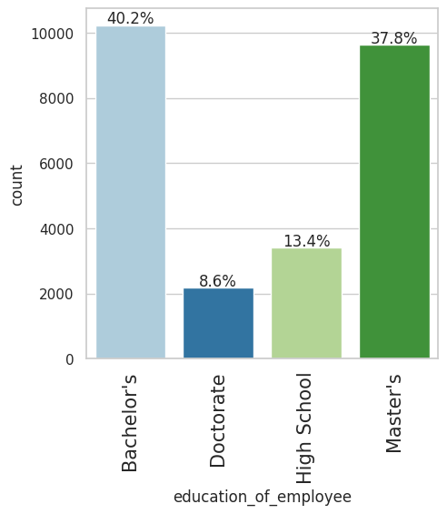

```python
labeled_barplot(data,'education_of_employee',perc=True)
```

#### Observations

- **Bachelor’s degree holders form the largest group (≈40.2%)**, indicating this is the most common educational qualification.
- **Master’s degree holders are a close second (≈37.8%)**, together with Bachelor’s accounting for nearly **78%** of the total.
- **High School graduates represent about 13.4%**, a significantly smaller share compared to degree holders.
- **Doctorate holders are the least represented (≈8.6%)** in the dataset.
- Overall, the distribution is **heavily skewed toward higher education**, with the majority of employees holding at least a Bachelor’s degree.

#### Observations on region of employment

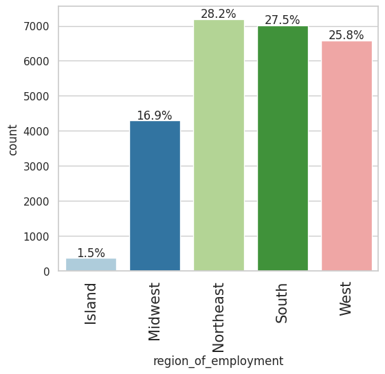

```python
labeled_barplot(data,'region_of_employment',perc=True)
```

#### Observations

- The Northeast region has the highest number of employees, accounting for 28.2% of the total.
- The South region is the second largest, representing 27.5%.
- The West region makes up 25.8% of the employment.
- The Midwest region accounts for 16.9%.
- The Island region has the fewest employees, with only 1.5%.
- The majority of employees are located in the Northeast, South, and West regions.

#### Observations on job experience

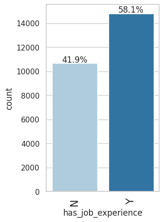

```python
labeled_barplot(data,'has_job_experience',perc=True)
```

#### Observations

- The category for having job experience, labeled "Y" (Yes), is the majority.
- 58.1% of the individuals in the dataset have job experience.
- 41.9% of the individuals do not have job experience, labeled "N" (No).
- There are more people with job experience than those without job experience.

#### Observations on case status

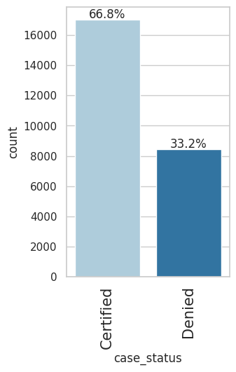

```python
labeled_barplot(data,'case_status',perc=True)
```

#### Observations on Continent

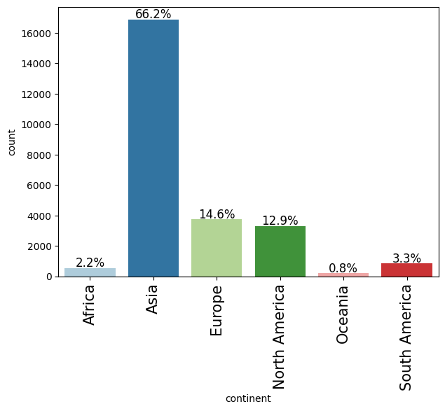

```python
labeled_barplot(data,'continent',perc=True)
```

#### Observation

- Asia has the highest count and the largest share of the total, accounting for 66.2% of observations (around 16,000 counts).
- Europe is the second-largest category, representing 14.6% of the data.
- North America is close behind Europe with 12.9% of the observations.
- The remaining continents have significantly smaller proportions:
  - South America accounts for 3.3%.
  - Africa accounts for 2.2%.
  - Oceania accounts for the smallest share at only 0.8%.
- The vast majority of the data is concentrated in the Asian continent bar.

#### Observation on Prevailing Wage

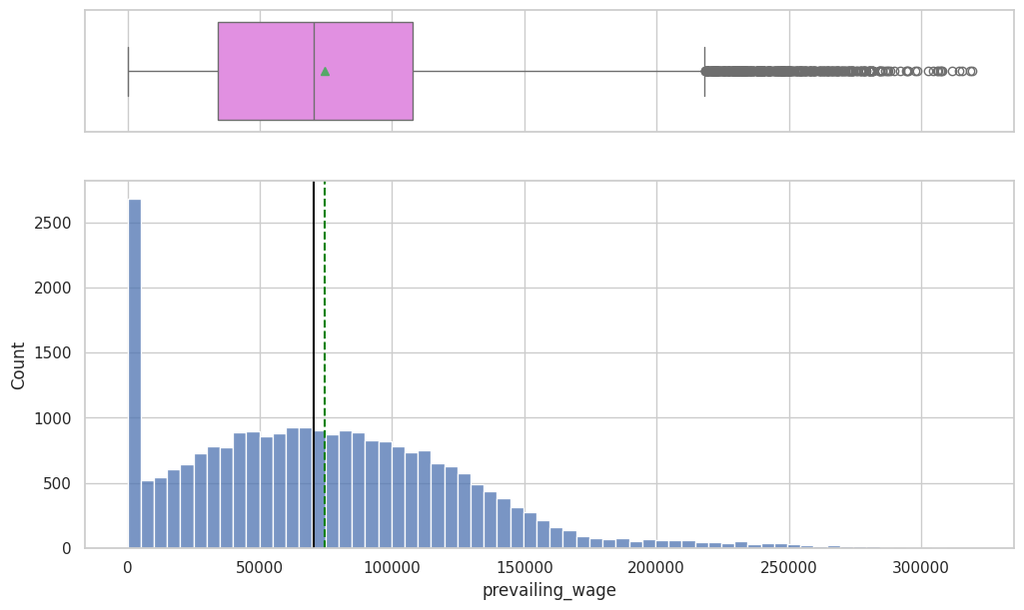

```python
# Plotting the Prevailing Wage
histogram_boxplot(data,'prevailing_wage')
```

#### Observations

- The data is highly skewed to the right, meaning most values are lower.
- The majority of wages are concentrated below $75,000
- The median wage is approximately $70,000.
- There are numerous outliers with very high wage values (above ($200,000)).
- A data transformation (like log-scaling) would likely be beneficial for modeling this feature.

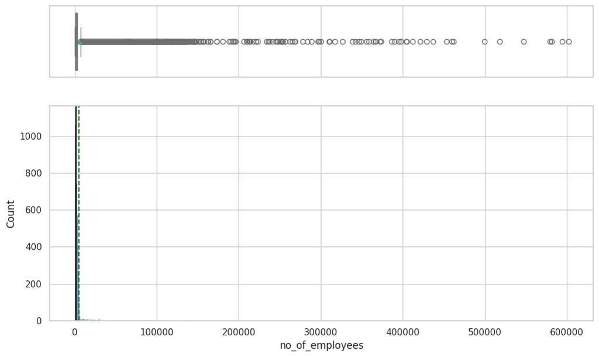

```python
histogram_boxplot(data, 'no_of_employees')
```

### Bivariate Analysis

```python
### function to plot distributions wrt target


def distribution_plot_wrt_target(data, predictor, target):

    fig, axs = plt.subplots(2, 2, figsize=(12, 10))

    target_uniq = data[target].unique()

    axs[0, 0].set_title("Distribution of target for target=" + str(target_uniq[0]))
    sns.histplot(
        data=data[data[target] == target_uniq[0]],
        x=predictor,
        kde=True,
        ax=axs[0, 0],
        color="teal",
        stat="density",
    )

    axs[0, 1].set_title("Distribution of target for target=" + str(target_uniq[1]))
    sns.histplot(
        data=data[data[target] == target_uniq[1]],
        x=predictor,
        kde=True,
        ax=axs[0, 1],
        color="orange",
        stat="density",
    )

    axs[1, 0].set_title("Boxplot w.r.t target")
    sns.boxplot(data=data, x=target, y=predictor, ax=axs[1, 0], palette="gist_rainbow")

    axs[1, 1].set_title("Boxplot (without outliers) w.r.t target")
    sns.boxplot(
        data=data,
        x=target,
        y=predictor,
        ax=axs[1, 1],
        showfliers=False,
        palette="gist_rainbow",
    )

    plt.tight_layout()
    plt.show()
```

```python
def stacked_barplot(data, predictor, target):
    """
    Print the category counts and plot a stacked bar chart

    data: dataframe
    predictor: independent variable
    target: target variable
    """
    count = data[predictor].nunique()
    sorter = data[target].value_counts().index[-1]
    tab1 = pd.crosstab(data[predictor], data[target], margins=True).sort_values(
        by=sorter, ascending=False
    )
    print(tab1)
    print("-" * 120)
    tab = pd.crosstab(data[predictor], data[target], normalize="index").sort_values(
        by=sorter, ascending=False
    )
    tab.plot(kind="bar", stacked=True, figsize=(count + 5, 5))
    plt.legend(
        loc="lower left", frameon=False,
    )
    plt.legend(loc="upper left", bbox_to_anchor=(1, 1))
    plt.show()
```

```python
def stacked_barplot(
    data,
    predictor,
    target,
    figsize=None,
    sort_by=None,
    normalize=True,
    palette="Set2"
):
    """
    Display category counts and plot a stacked bar chart with improved colors.

    Parameters
    ----------
    data : pd.DataFrame
    predictor : str
        X-axis categorical variable
    target : str
        Stacked categorical variable
    figsize : tuple, optional
    sort_by : str, optional
        Target category to sort by
    normalize : bool, default=True
        Plot proportions instead of counts
    palette : str, default="tab10"
        Matplotlib colormap name
    """

    if predictor not in data.columns or target not in data.columns:
        raise ValueError("Predictor or target column not found in dataframe")

    # Crosstab
    count_tab = pd.crosstab(data[predictor], data[target])

    # Sorting
    if sort_by is None:
        sort_by = count_tab.sum().idxmax()

    count_tab = count_tab.sort_values(by=sort_by, ascending=False)

    # Print counts
    print(pd.crosstab(data[predictor], data[target], margins=True))
    print("-" * 120)

    # Normalize if required
    plot_tab = (
        count_tab.div(count_tab.sum(axis=1), axis=0)
        if normalize
        else count_tab
    )

    # Figure size
    if figsize is None:
        figsize = (max(8, len(plot_tab) + 3), 5)

    # Generate colors dynamically
    cmap = cm.get_cmap(palette, plot_tab.shape[1])
    colors = [cmap(i) for i in range(plot_tab.shape[1])]

    # Plot
    ax = plot_tab.plot(
        kind="bar",
        stacked=True,
        figsize=figsize,
        color=colors,
        edgecolor="white",
        linewidth=0.6
    )

    ax.set_xlabel(predictor)
    ax.set_ylabel("Proportion" if normalize else "Count")
    ax.set_title(f"{predictor} vs {target}")

    ax.legend(
        title=target,
        loc="upper left",
        bbox_to_anchor=(1, 1),
        frameon=False
    )

    plt.tight_layout()
    plt.show()
```

#### Does higher education increase the chances of visa certification for well-paid jobs abroad?

```
case_status            Certified  Denied    All
education_of_employee
Bachelor's                  6367    3867  10234
Doctorate                   1912     280   2192
High School                 1164    2256   3420
Master's                    7575    2059   9634
All                        17018    8462  25480
------------------------------------------------------------------------------------------------------------------------
```

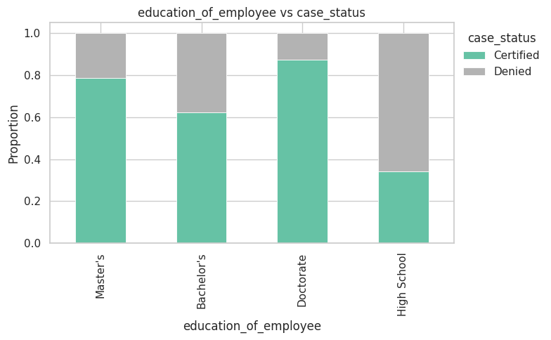

```python
# Relation between education and case status
stacked_barplot(data, 'education_of_employee', 'case_status')
```

#### Observations:

- Doctorate: This group has the highest proportion of certifications, with over 85% of applicants certified (around 1,912 certified vs. 280 denied).
- Master's: Applicants with a Master's degree also show a very high certification rate, with over 75% of cases certified (around 7,575 certified vs. 2,059 denied).
- Bachelor's: The certification rate is significantly lower for Bachelor's degree holders, at approximately 62% certified (around 6,367 certified vs. 3,867 denied).
- High School: This group has the lowest approval rate, with only about 34% of applicants receiving certification, meaning approximately 65% were denied (around 1,164 certified vs. 2,256 denied).

Answer to the Question

- Yes, based on the provided data, a higher level of education strongly correlates with an increased chance of visa certification. The data indicates that as the level of education increases from High School to Doctorate, the ratio of certified to denied applications improves considerably. The highest educated groups (Doctorate and Master's) have significantly higher certification rates (over 75%) compared to those with a Bachelor's degree or High School diploma (around 62% and 34%, respectively)

#### How does visa status vary across different continents?

```
case_status    Certified  Denied    All
continent
Africa               397     154    551
Asia               11012    5849  16861
Europe              2957     775   3732
North America       2037    1255   3292
Oceania              122      70    192
South America        493     359    852
All                17018    8462  25480
------------------------------------------------------------------------------------------------------------------------
```

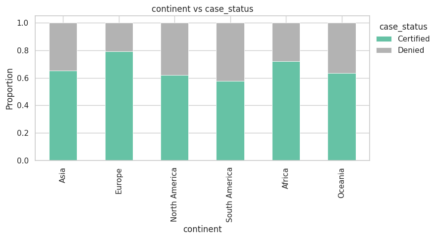

```python
# Relation between Continent and Case Status
stacked_barplot(data,'continent','case_status')
```

#### Observations

- Asia has the overwhelming majority of total applications, accounting for 16,861 out of 25,480 total applications (around 66%).
- The overall visa approval rate (Certified status) across all continents is approximately 66.8% (17,018 out of 25,480 total applications).
- Europe has the highest proportion of certified visa applications, with approximately 79.2% (2,957 out of 3,732) receiving certified status.
- South America has the lowest approval rate with a little below 60%.

#### Does having prior work experience influence the chances of visa certification for career opportunities abroad?

```
case_status         Certified  Denied    All
has_job_experience
N                        5994    4684  10678
Y                       11024    3778  14802
All                     17018    8462  25480
------------------------------------------------------------------------------------------------------------------------
```

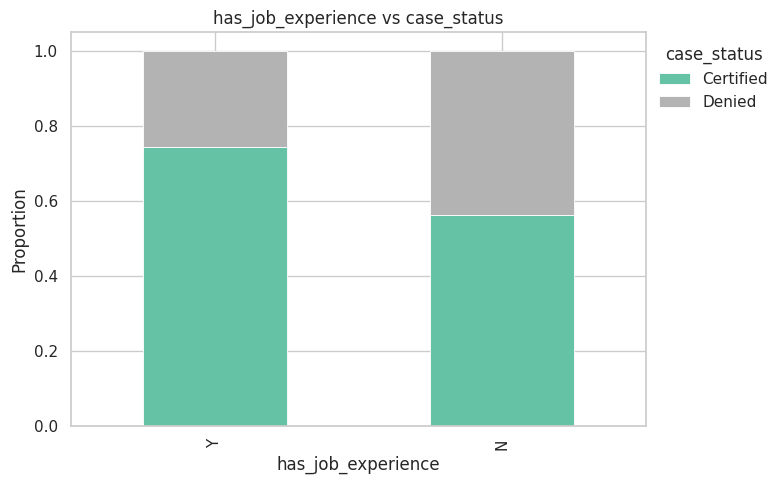

```python
# Relation between job experience and case status
stacked_barplot(data, 'has_job_experience', 'case_status')
```

#### Observations

Yes, having prior work experience positively influences the chances of visa certification for career opportunities abroad, based on the provided data.

Here are the key observations from the data:

- A significantly higher proportion of applicants with job experience (Y) received certified status (around 74.5%) compared to those without job experience (N) (around 56.1%).
- The overall denial rate is much higher for applicants who did not have job experience (approximately 43.9% denied) than for those who did (approximately 25.5% denied).
- The majority of total applicants in this dataset (14,802 out of 25,480, or ~58%) reported having job experience.
- Applicants with job experience are nearly 1.3 times more likely to get their visa certified than those without experience.

#### Is the prevailing wage consistent across all regions of the US?

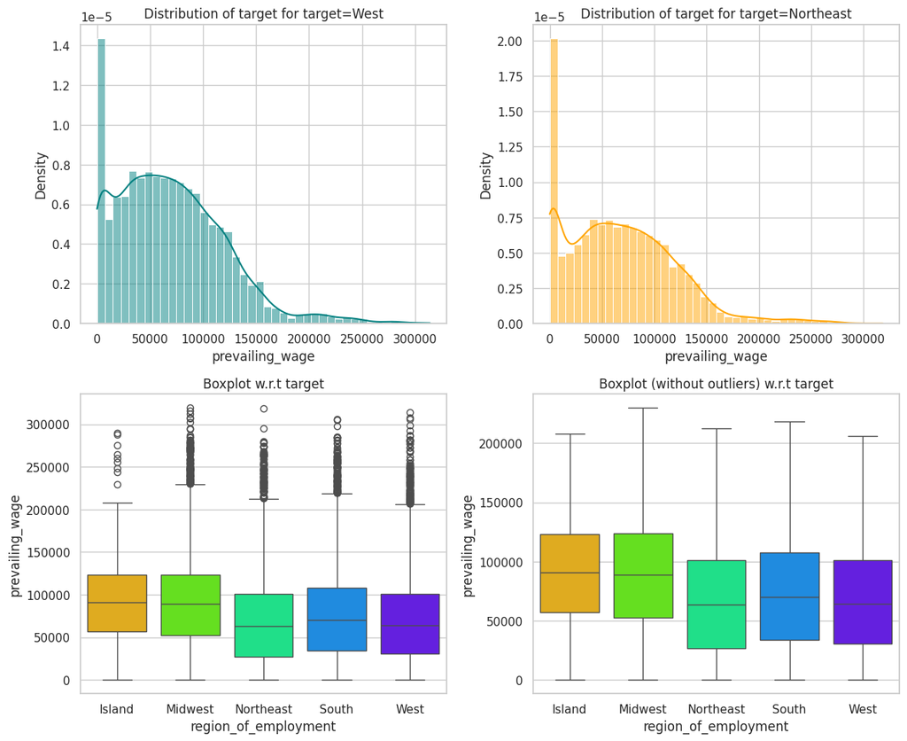

```python
# Relation between Prevailing Wage and Region of Employment
distribution_plot_wrt_target(data, 'prevailing_wage', 'region_of_employment')
```

#### Observations

No, the prevailing wage is not consistent across all regions of the US; there are clear differences in the typical wage ranges and medians as shown in the box plot.

#### Does visa status vary with changes in the prevailing wage set to protect both local talent and foreign workers?

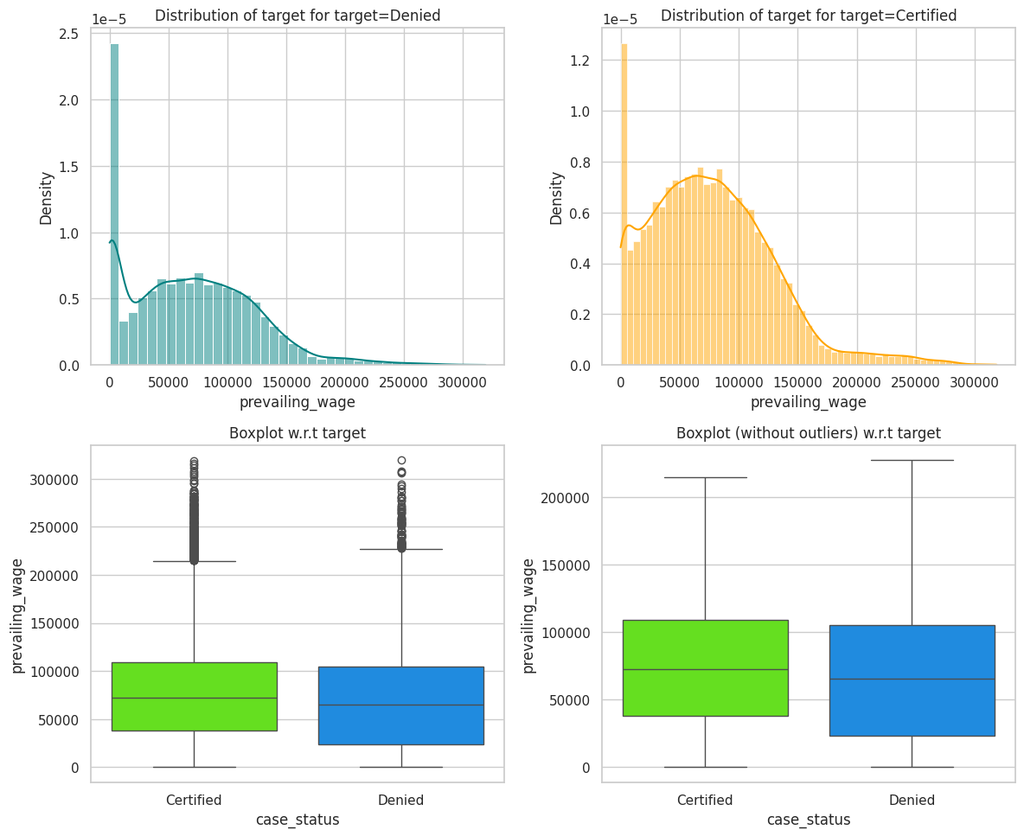

```python
# Relation between Prevaling Wage and Case Status
distribution_plot_wrt_target(data,"prevailing_wage","case_status")
```

#### Observations

- There isn't much difference between certified and denied case status in relation to prevailing wage.
- Denied cases have a slightly lower median than certified.

#### Does the unit of prevailing wage (Hourly, Weekly, etc.) have any impact on the likelihood of visa application certification?

```
case_status   Certified  Denied    All
unit_of_wage
Hour                747    1410   2157
Month                55      34     89
Week                169     103    272
Year              16047    6915  22962
All               17018    8462  25480
------------------------------------------------------------------------------------------------------------------------
```

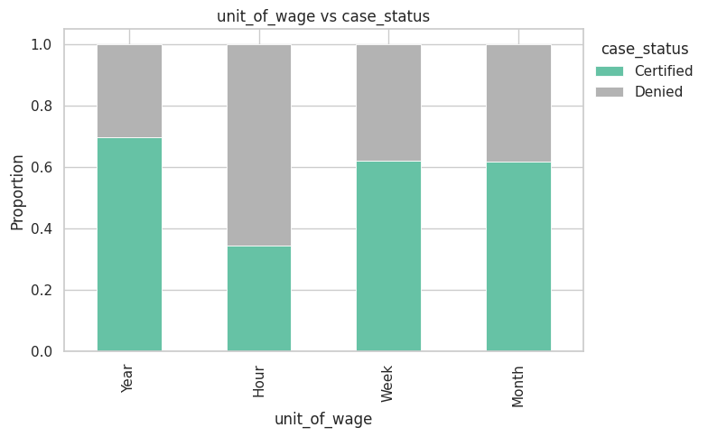

```python
## Plotting stacked barplot for unit of wage and case status
stacked_barplot(data,"unit_of_wage","case_status")
```

#### Observations

Yes, the unit of prevailing wage appears to have a significant impact on the likelihood of visa application certification.

Here are key observations:

- The most common unit of wage in the dataset is Year, accounting for the vast majority of all applications (around 90%).
- Applications submitted with a yearly wage unit have the highest certification rate, at approximately 70%.
- Applications submitted with an hourly wage unit have the lowest certification rate by a large margin, at only around 34.6%.
- Weekly and monthly wage units have similar moderate certification rates, both slightly above 60%.
- The stack bar plot visually confirms that the proportion of certified cases (green) is much smaller for the "Hour" unit compared to the "Year", "Week", and "Month" units.

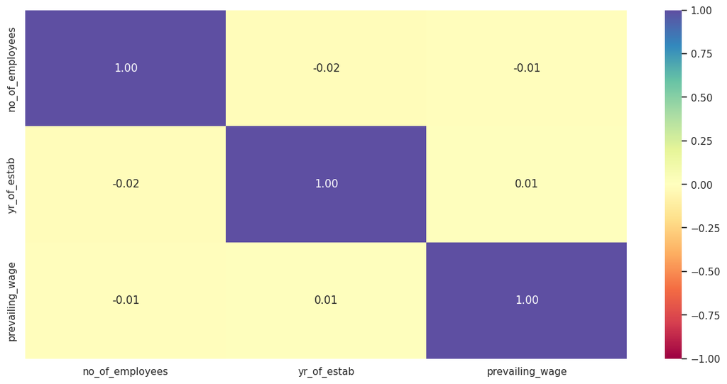

```python
plt.figure(figsize=(15, 7))
sns.heatmap(data.corr(numeric_only=True), annot=True, vmin=-1, vmax=1, fmt=".2f", cmap="Spectral")
plt.show()
```

#### Observations

- All variables exhibit a perfect positive correlation of 1.00 with themselves, as indicated by the main diagonal of the matrix.
- There is a very weak positive correlation (0.01) between the year of establishment ((yr_of_estab)) and the prevailing wage, suggesting almost no linear relationship between when a company was founded and the wages it pays.- - The correlation between the number of employees ((no_of_employees)) and the year of establishment is also very weak, specifically a minimal negative correlation of -0.02, which suggests a negligible inverse relationship between these two variables.
- Similarly, there is an extremely weak negative correlation (-0.01) between the number of employees and the prevailing wage, implying that the size of a company has little to no impact on the average wages it offers, or vice versa.
- Overall, the correlation coefficients between all variable pairings are very close to zero, ranging from -0.02 to 0.01. This signifies that there are no notable linear relationships among the number of employees, year of establishment, and prevailing wage variables in this dataset.

## Data Pre-processing

### Outlier Check

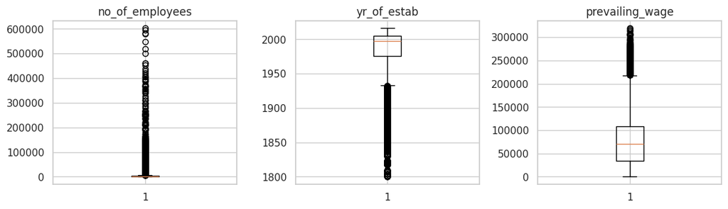

```python
# Outlier detection using boxplot
num_cols = data.select_dtypes(include=np.number).columns.tolist()

plt.figure(figsize=(15, 12))

for i, variable in enumerate(num_cols):
    plt.subplot(4, 4, i + 1)
    plt.boxplot(data[variable], whis=1.5)
    plt.tight_layout()
    plt.title(variable)

plt.show()
```

### Data Preparation for modeling

- We want to predict which visa will be certified.
- Before we proceed to build a model, we'll have to encode categorical features.
- We'll split the data into train and test to be able to evaluate the model that we build on the train data.

```python
# replacing 'certified' with 1 and 'denied' with 0
data.case_status = data.case_status.apply(lambda x:1 if x =="Certified" else 0)
 # checking rows updates
data.sample(10)
```

|  | continent | education_of_employee | has_job_experience | requires_job_training | no_of_employees | yr_of_estab | region_of_employment | prevailing_wage | unit_of_wage | full_time_position | case_status |
| --- | --- | --- | --- | --- | --- | --- | --- | --- | --- | --- | --- |
| 2188 | Asia | Master's | Y | N | 5072 | 1975 | West | 15260.08 | Year | Y | 1 |
| 6177 | Asia | Master's | Y | N | 776 | 2006 | West | 147561.92 | Year | Y | 1 |
| 7725 | Asia | Master's | N | N | 3699 | 2016 | South | 43416.41 | Year | Y | 1 |
| 22117 | Europe | Master's | Y | N | 1867 | 1993 | Northeast | 54070.79 | Year | Y | 1 |
| 15416 | Asia | High School | N | Y | 5219 | 1954 | West | 126826.57 | Year | Y | 0 |
| 7929 | Europe | Bachelor's | Y | N | 2431 | 1855 | Midwest | 171335.05 | Year | Y | 0 |
| 203 | Asia | Master's | N | N | 4757 | 1981 | Midwest | 167376.13 | Year | Y | 1 |
| 6139 | Asia | Doctorate | N | N | 1829 | 2012 | West | 122674.76 | Year | Y | 1 |
| 2331 | North America | Master's | Y | N | 7999 | 1996 | Northeast | 100078.42 | Year | N | 1 |
| 11278 | Asia | Master's | N | N | 2453 | 1997 | South | 88831.10 | Year | Y | 0 |

```python
#create a dataframe of the predictor feature columns
X = data.drop('case_status',axis=1)

#create a dataframe of the predicted class (1=True, 0=False)
Y = data['case_status']

#generate dummy variables for each categorical variable
X = pd.get_dummies(X, drop_first=True)

X.sample(10)
```

|  | no_of_employees | yr_of_estab | prevailing_wage | continent_Asia | continent_Europe | continent_North America | continent_Oceania | continent_South America | education_of_employee_Doctorate | education_of_employee_High School | education_of_employee_Master's | has_job_experience_Y | requires_job_training_Y | region_of_employment_Midwest | region_of_employment_Northeast | region_of_employment_South | region_of_employment_West | unit_of_wage_Month | unit_of_wage_Week | unit_of_wage_Year | full_time_position_Y |
| --- | --- | --- | --- | --- | --- | --- | --- | --- | --- | --- | --- | --- | --- | --- | --- | --- | --- | --- | --- | --- | --- |
| 22261 | 849 | 2006 | 94410.25 | True | False | False | False | False | False | False | True | False | True | False | False | False | True | False | False | True | True |
| 21317 | 3431 | 1992 | 130002.47 | True | False | False | False | False | False | False | True | False | False | False | True | False | False | False | False | True | False |
| 9287 | 3196 | 1985 | 89146.50 | False | False | True | False | False | False | False | True | True | False | False | False | False | True | False | False | True | True |
| 6130 | 3907 | 1986 | 126269.34 | True | False | False | False | False | False | False | True | True | False | False | False | True | False | False | False | True | True |
| 9393 | 1775 | 1999 | 91696.75 | True | False | False | False | False | False | False | True | True | False | True | False | False | False | False | False | True | True |
| 21838 | 902 | 2005 | 68955.42 | False | False | False | False | False | False | True | False | True | False | False | True | False | False | False | False | True | True |
| 24214 | 80749 | 2011 | 102084.12 | True | False | False | False | False | False | False | False | True | False | False | False | False | False | False | False | True | False |
| 4895 | 1972 | 1997 | 13358.90 | True | False | False | False | False | False | False | False | False | False | False | True | False | False | False | False | True | True |
| 5798 | 4785 | 2007 | 66894.66 | True | False | False | False | False | False | False | True | True | False | False | False | True | False | False | False | True | True |
| 10315 | 2426 | 2005 | 81096.52 | True | False | False | False | False | False | True | False | False | False | True | False | False | False | False | False | True | True |

```python
# Lets split the data in 70:15:15 ratio for train to test to validation data
X_train, X_test, Y_train, Y_test =train_test_split(X, Y, test_size=0.30, random_state=1, shuffle=True)
X_val, X_test, Y_val, Y_test = train_test_split(X_test, Y_test, test_size=0.5, random_state=1, stratify=Y_test)
```

```python
# Better output visualization for dataset splits
print("Dataset Split Overview")
print("=" * 40)

# Shapes of the splits
print(f"Training set:   X_train = {X_train.shape}, y_train = {Y_train.shape}")
print(f"Validation set: X_val   = {X_val.shape}, y_val   = {Y_val.shape}")
print(f"Test set:       X_test  = {X_test.shape}, y_test  = {Y_test.shape}")
print("-" * 40)

# Class distribution in each split
for split_name, y_split in [("Training", Y_train), ("Validation", Y_val), ("Test", Y_test)]:
    print(f"{split_name} set class distribution (%):")
    print((y_split.value_counts(normalize=True) * 100).round(2))
    print("-" * 40)
```

```
Dataset Split Overview
========================================
Training set:   X_train = (17836, 21), y_train = (17836,)
Validation set: X_val   = (3822, 21), y_val   = (3822,)
Test set:       X_test  = (3822, 21), y_test  = (3822,)
----------------------------------------
Training set class distribution (%):
case_status
1    66.36
0    33.64
Name: proportion, dtype: float64
----------------------------------------
Validation set class distribution (%):
case_status
1    67.79
0    32.21
Name: proportion, dtype: float64
----------------------------------------
Test set class distribution (%):
case_status
1    67.79
0    32.21
Name: proportion, dtype: float64
----------------------------------------
```

## Model Building

### Model Evaluation Criterion

Model can make wrong predictions as:

- Predicting an applicant should be approved the applicant is denied.
- Predicting an applicant should be denied and the applicant is approved.

## Which case is more important?

Both are important:

- If an applicant is approved when they would have been denied, an unqualified employee will get a job that should have been filled by a US citizen.
- If an applicant is denied when they should have been approved, U.S. companies will not be able to fill critical positions and the overall economy will not be as productive.

### How to reduce the losses?

- As the process of reviewing each application is time and resource-intensive, this model should identify those candidates predicted to be approved, so agents can prioritize these applications.
- F1 Score can be used a the metric for evaluation of the model, as the greater the F1 score, the higher the chances of minimizing False Negatives and False Positives.
- Will use balanced class weights, where applicable, so that model focuses equally on both classes.
- Will fit different models on the train data and observe their performance. - Will try to improve that performance by tuning some hyperparameters available for that algorithm.
- Will use GridSearchCv for hyperparameter tuning and F1 score to optimize the model.

First, let's create functions to calculate different metrics and confusion matrix so that we don't have to use the same code repeatedly for each model.

- The `model_performance_classification_sklearn` function will be used to check the model performance of models.
- The `confusion_matrix_sklearn` function will be used to plot the confusion matrix.

```python
# defining a function to compute different metrics to check performance of a classification model built using sklearn


def model_performance_classification_sklearn(model, predictors, target):
    """
    Function to compute different metrics to check classification model performance

    model: classifier
    predictors: independent variables
    target: dependent variable
    """

    # predicting using the independent variables
    pred = model.predict(predictors)

    acc = accuracy_score(target, pred)  # to compute Accuracy
    recall = recall_score(target, pred)  # to compute Recall
    precision = precision_score(target, pred)  # to compute Precision
    f1 = f1_score(target, pred)  # to compute F1-score

    # creating a dataframe of metrics
    df_perf = pd.DataFrame(
        {"Accuracy": acc, "Recall": recall, "Precision": precision, "F1": f1,},
        index=[0],
    )

    return df_perf
```

```python
def confusion_matrix_sklearn(model, predictors, target):
    """
    To plot the confusion_matrix with percentages

    model: classifier
    predictors: independent variables
    target: dependent variable
    """
    y_pred = model.predict(predictors)
    cm = confusion_matrix(target, y_pred)
    labels = np.asarray(
        [
            ["{0:0.0f}".format(item) + "\n{0:.2%}".format(item / cm.flatten().sum())]
            for item in cm.flatten()
        ]
    ).reshape(2, 2)

    plt.figure(figsize=(6, 4))
    sns.heatmap(cm, annot=labels, fmt="")
    plt.ylabel("True label")
    plt.xlabel("Predicted label")
```

```python
def plot_prec_recall_vs_tresh(precisions, recalls, thresholds):
    plt.plot(thresholds, precisions[:-1], "b--", label="precision")
    plt.plot(thresholds, recalls[:-1], "g--", label="recall")
    plt.xlabel("Threshold")
    plt.legend(loc="upper left")
    plt.ylim([0, 1])
```

**We are now done with pre-processing and evaluation criterion, so let's start building the model.**

Proposed ML Model Building Plan

1. Define the evaluation metric
   - Use F1-score as the primary metric (especially for imbalanced datasets)
   - Optionally, track accuracy, precision, and recall for a complete performance view.
2. Train multiple baseline models
   - Use the original dataset to train a set of candidate models (e.g., Decision Tree, Random Forest, Gradient Boosting, XGBoost, etc.).
3. Evaluate baseline models
   - Compare models using cross-validation scores for F1, accuracy, precision, and recall.
4. Address class imbalance
   - Train models using oversampled, undersampled, or hybrid datasets.
   - Compare their CV performance with the original dataset to see the impact of sampling.
5. Hyperparameter tuning
   - Perform GridSearchCV / RandomizedSearchCV to optimize model hyperparameters.
   - Use cross-validation during tuning to ensure robust performance.
6. Final model evaluation
   - Compare all candidate models on the validation set using all relevant metrics (F1, precision, recall, accuracy).
   - Select the best-performing model, justifying the choice based on metrics, stability, and business relevance.
7. Insights and recommendations
   - Explain why the selected model works best.
   - Provide actionable insights, such as variables with high importance, expected performance in production, and potential limitations.

#### Decision Tree Model

We will build our model using the DecisionTreeClassifier function, using default 'gini' criteria to split.

```python
dtree = DecisionTreeClassifier(criterion='gini', random_state=1, class_weight='balanced')
dtree.fit(X_train, Y_train)
```

```
DecisionTreeClassifier(class_weight='balanced', random_state=1)
```

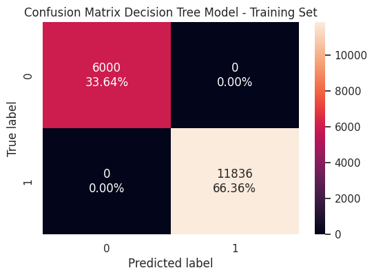

```python
#Checking model performance on training data
confusion_matrix_sklearn(dtree, X_train, Y_train)
plt.title("Confusion Matrix Decision Tree Model - Training Set");
```

```python
dtree_model_train_perf = model_performance_classification_sklearn(
    dtree, X_train, Y_train
)
print("Training performance \n")
dtree_model_train_perf
```

```
Training performance
```

|  | Accuracy | Recall | Precision | F1 |
| --- | --- | --- | --- | --- |
| 0 | 1.0 | 1.0 | 1.0 | 1.0 |

#### Observations

- The model achieves a perfect classification score on the training data, as there are zero false positives and zero false negatives
- There are 6,000 true negative predictions (True Label 0, Predicted Label 0), accounting for 33.64% of the total samples
- There are 11,836 true positive predictions (True Label 1, Predicted Label 1), accounting for 66.36% of the total samples
- The total number of samples in the training set is 17,836 (6,000 + 11,836)

[figure not shown]

```python
confusion_matrix_sklearn(dtree, X_test, Y_test)
plt.title("Confusion Matrix Decision Tree Model - Test Set");
```

```python
dtree_model_test_perf=model_performance_classification_sklearn(dtree, X_test, Y_test)
print("Testing performance \n")
dtree_model_test_perf
```

```
Testing performance
```

|  | Accuracy | Recall | Precision | F1 |
| --- | --- | --- | --- | --- |
| 0 | 0.667713 | 0.753763 | 0.755513 | 0.754637 |

The Decision Tree is working well on the training data, but is not able to generalize well on the test data, indicating the model is overfit.

#### Bagging Classifier

```python
bagging = BaggingClassifier(random_state=1)
bagging.fit(X_train,Y_train)
```

```
BaggingClassifier(random_state=1)
```

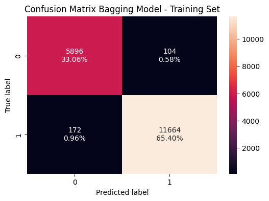

```python
#Checking model performance on training data
confusion_matrix_sklearn(bagging, X_train, Y_train)
plt.title("Confusion Matrix Bagging Model - Training Set");
```

```python
bagging_model_train_perf=model_performance_classification_sklearn(bagging, X_train, Y_train)
print("Training performance Bagging Model\n")
bagging_model_train_perf
```

```
Training performance Bagging Model
```

|  | Accuracy | Recall | Precision | F1 |
| --- | --- | --- | --- | --- |
| 0 | 0.984526 | 0.985468 | 0.991162 | 0.988307 |

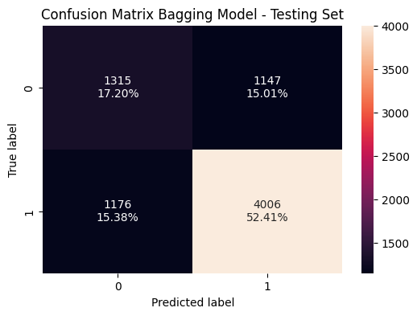

```python
#Checking model performance on testing data
confusion_matrix_sklearn(bagging, X_test, Y_test)
plt.title("Confusion Matrix Bagging Model - Testing Set");
```

```python
bagging_model_test_perf=model_performance_classification_sklearn(bagging,X_test, Y_test)
print("Testing performance Bagging Model \n")
bagging_model_test_perf
```

```
Testing performance Bagging Model
```

|  | Accuracy | Recall | Precision | F1 |
| --- | --- | --- | --- | --- |
| 0 | 0.684982 | 0.761868 | 0.770793 | 0.766304 |

#### Observation

- Similar to the Decision Tree model, this bagging classifer is overfit to the training dataset but has a higher F1 score.

#### Random Forest

```python
rf = RandomForestClassifier(random_state=1)
rf.fit(X_train,Y_train)
```

```
RandomForestClassifier(random_state=1)
```

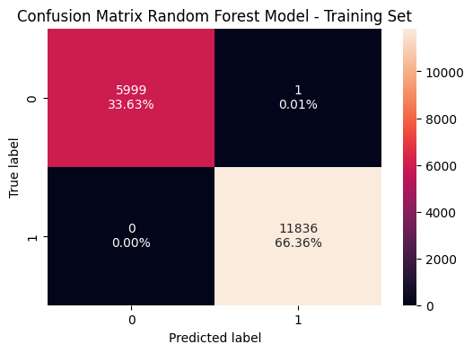

```python
#Checking model performance on training data
confusion_matrix_sklearn(rf, X_train, Y_train)
plt.title("Confusion Matrix Random Forest Model - Training Set");
```

```python
rf_model_train_perf=model_performance_classification_sklearn(rf,X_train,Y_train)
print("Training performance Random Forest Model \n")
rf_model_train_perf
```

```
Training performance Random Forest Model
```

|  | Accuracy | Recall | Precision | F1 |
| --- | --- | --- | --- | --- |
| 0 | 0.999944 | 1.0 | 0.999916 | 0.999958 |

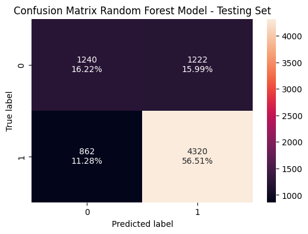

```python
#Checking model performance on testing data
confusion_matrix_sklearn(rf, X_test, Y_test)
plt.title("Confusion Matrix Random Forest Model - Testing Set");
```

```python
rf_model_test_perf=model_performance_classification_sklearn(rf,X_test,Y_test)
print("Testing performance Random Forest Model \n")
rf_model_test_perf
```

```
Testing performance Random Forest Model
```

|  | Accuracy | Recall | Precision | F1 |
| --- | --- | --- | --- | --- |
| 0 | 0.722658 | 0.830181 | 0.776254 | 0.802313 |

#### Observations

- Similar to the models above, this Random Forest is also overfit to the training dataset but has the highest F1 score so far.

#### AdaBoost Classifier

```python
ab_classifier=AdaBoostClassifier(random_state=1)
ab_classifier.fit(X_train,Y_train)
```

```
AdaBoostClassifier(random_state=1)
```

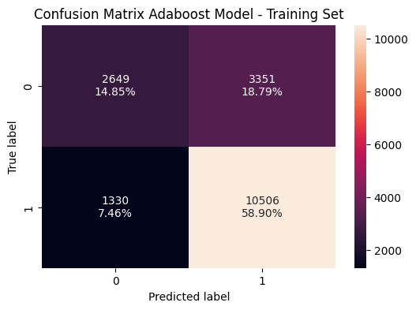

```python
#Checking model performance on training data
confusion_matrix_sklearn(ab_classifier, X_train, Y_train)
plt.title("Confusion Matrix Adaboost Model - Training Set");
```

```python
ab_classifier_model_train_perf = model_performance_classification_sklearn(ab_classifier,X_train,Y_train)
print("Training performance Adaboost Model\n")
ab_classifier_model_train_perf
```

```
Training performance Adaboost Model
```

|  | Accuracy | Recall | Precision | F1 |
| --- | --- | --- | --- | --- |
| 0 | 0.737553 | 0.887631 | 0.758173 | 0.81781 |

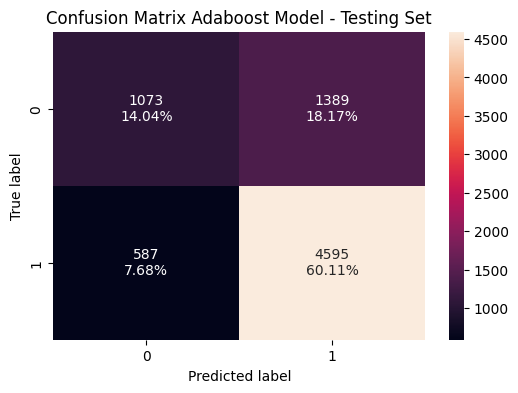

```python
#Checking model performance on testing data
confusion_matrix_sklearn(ab_classifier, X_test, Y_test)
plt.title("Confusion Matrix Adaboost Model - Testing Set");
```

```python
ab_classifier_model_test_perf = model_performance_classification_sklearn(ab_classifier,X_test,Y_test)
print("Testing performance Adaboost Model \n")
ab_classifier_model_test_perf
```

```
Testing performance Adaboost Model
```

|  | Accuracy | Recall | Precision | F1 |
| --- | --- | --- | --- | --- |
| 0 | 0.740188 | 0.883829 | 0.767941 | 0.821819 |

#### Observations

- This AdaBoost classifer performs equally well on the training and testing datasets, indicating that the model is not overfit.
- Additionally, the model performs the best of any model yet (i.e., highest F1 score) on the testing data.

#### Gradient Boosting Classifier

```python
gbc = GradientBoostingClassifier(random_state=1)
gbc.fit(X_train,Y_train)
```

```
GradientBoostingClassifier(random_state=1)
```

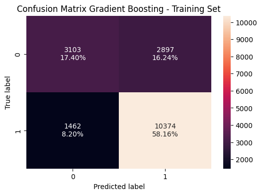

```python
#Checking model performance on training data
confusion_matrix_sklearn(gbc, X_train, Y_train)
plt.title("Confusion Matrix Gradient Boosting - Training Set");
```

```python
gbc_classifier_model_train_perf = model_performance_classification_sklearn(gbc,X_train,Y_train)
print("Training performance Gradient Boosting Model \n")
gbc_classifier_model_train_perf
```

```
Training performance Gradient Boosting Model
```

|  | Accuracy | Recall | Precision | F1 |
| --- | --- | --- | --- | --- |
| 0 | 0.755607 | 0.876479 | 0.781704 | 0.826383 |

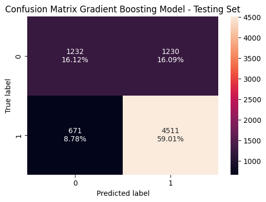

```python
#Checking model performance on testing data
confusion_matrix_sklearn(gbc, X_test, Y_test)
plt.title("Confusion Matrix Gradient Boosting Model - Testing Set");
```

```python
gbc_classifier_model_test_perf = model_performance_classification_sklearn(gbc,X_test,Y_test)
print("Training performance Gradient Boosting Model \n")
gbc_classifier_model_test_perf
```

```
Training performance Gradient Boosting Model
```

|  | Accuracy | Recall | Precision | F1 |
| --- | --- | --- | --- | --- |
| 0 | 0.750916 | 0.868391 | 0.786438 | 0.825385 |

#### Observations

- This Gradient Boosting classifer performs equally well on the training and testing datasets, indicating that the model is not overfit.
- Additionally, this model performs even better than the AdaBoost model above.

#### XGBoost Classifier

```python
xgb = XGBClassifier(random_state=1,eval_metric='logloss')
xgb.fit(X_train,Y_train)
```

```
XGBClassifier(base_score=None, booster=None, callbacks=None,
              colsample_bylevel=None, colsample_bynode=None,
              colsample_bytree=None, device=None, early_stopping_rounds=None,
              enable_categorical=False, eval_metric='logloss',
              feature_types=None, feature_weights=None, gamma=None,
              grow_policy=None, importance_type=None,
              interaction_constraints=None, learning_rate=None, max_bin=None,
              max_cat_threshold=None, max_cat_to_onehot=None,
              max_delta_step=None, max_depth=None, max_leaves=None,
              min_child_weight=None, missing=nan, monotone_constraints=None,
              multi_strategy=None, n_estimators=None, n_jobs=None,
              num_parallel_tree=None, ...)
```

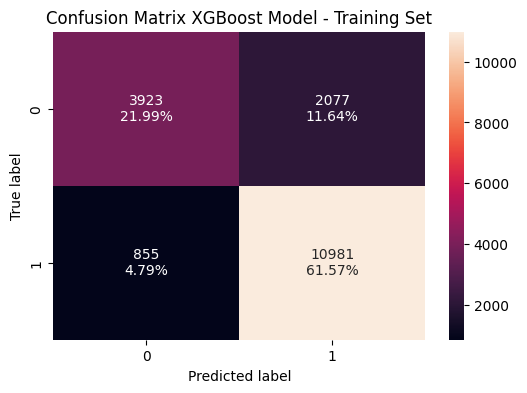

```python
#Checking model performance on training data
confusion_matrix_sklearn(xgb, X_train, Y_train)
plt.title("Confusion Matrix XGBoost Model - Training Set");
```

```python
xgb_classifier_model_train_perf = model_performance_classification_sklearn(xgb,X_train,Y_train)
print("Training performance XGBoost Model \n")
xgb_classifier_model_train_perf
```

```
Training performance XGBoost Model
```

|  | Accuracy | Recall | Precision | F1 |
| --- | --- | --- | --- | --- |
| 0 | 0.835613 | 0.927763 | 0.84094 | 0.882221 |

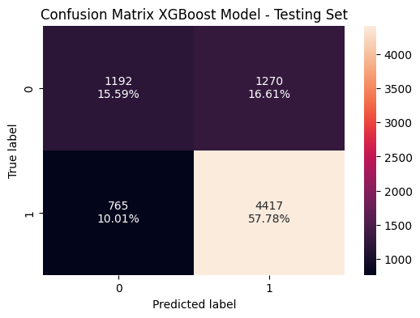

```python
#Checking model performance on testing data
confusion_matrix_sklearn(xgb, X_test, Y_test)
plt.title("Confusion Matrix XGBoost Model - Testing Set");
```

```python
xgb_classifier_model_test_perf = model_performance_classification_sklearn(xgb,X_test,Y_test)
print("Training performance XGBoost Model \n")
xgb_classifier_model_test_perf
```

```
Training performance XGBoost Model
```

|  | Accuracy | Recall | Precision | F1 |
| --- | --- | --- | --- | --- |
| 0 | 0.733386 | 0.850637 | 0.777151 | 0.812235 |

#### Compare models using cross-validation scores

```python
# -------------------------------------------------
# Define candidate models
# -------------------------------------------------
models = [
    ("Bagging", BaggingClassifier(random_state=1)),
    ("Random Forest", RandomForestClassifier(random_state=1)),
    ("Gradient Boosting", GradientBoostingClassifier(random_state=1)),
    ("AdaBoost", AdaBoostClassifier(random_state=1)),
    (
        "XGBoost",
        XGBClassifier(
            random_state=1,
            eval_metric="logloss",
            use_label_encoder=False
        )
    ),
    ("Decision Tree", DecisionTreeClassifier(random_state=1))
]

cv_results = []
model_names = []

# -------------------------------------------------
# Cross-validation performance
# -------------------------------------------------
print("\nCross-Validation Performance (Training Dataset)")
print("=" * 55)

kfold = StratifiedKFold(n_splits=5, shuffle=True, random_state=1)

for name, model in models:
    cv_scores = cross_val_score(
        estimator=model,
        X=X_train,
        y=Y_train,
        scoring=scorer,
        cv=kfold
    )

    cv_results.append(cv_scores)
    model_names.append(name)

    print(f"{name:<20} | Mean CV Score: {cv_scores.mean():.4f}")

# -------------------------------------------------
# Validation set performance
# -------------------------------------------------
print("\nValidation Set Performance")
print("=" * 55)

for name, model in models:
    model.fit(X_train, Y_train)

    y_pred = model.predict(X_val)
    f1 = f1_score(Y_val, y_pred)

    print(f"{name:<20} | F1 Score: {f1:.4f}")
```

```
Cross-Validation Performance (Training Dataset)
=======================================================
Bagging              | Mean CV Score: 0.7733
Random Forest        | Mean CV Score: 0.7994
Gradient Boosting    | Mean CV Score: 0.8215
AdaBoost             | Mean CV Score: 0.8171
XGBoost              | Mean CV Score: 0.8062
Decision Tree        | Mean CV Score: 0.7396

Validation Set Performance
=======================================================
Bagging              | F1 Score: 0.7841
Random Forest        | F1 Score: 0.8090
Gradient Boosting    | F1 Score: 0.8265
AdaBoost             | F1 Score: 0.8242
XGBoost              | F1 Score: 0.8133
Decision Tree        | F1 Score: 0.7505
```

```python
# Plotting boxplots for CV scores of all models defined above
fig = plt.figure(figsize=(10, 7))

fig.suptitle("Algorithm Comparison: Cross-Validation F1 Scores")
ax = fig.add_subplot(111)

plt.boxplot(results1)
ax.set_xticklabels(names)

plt.show()
```

[output not shown]

#### Base models comparison

```python
# creating a dataframe comparing the performance of the base models on the training data

models_train_comp_df = pd.concat(
    [dtree_model_train_perf.T,
     bagging_model_train_perf.T,
     rf_model_train_perf.T,
     ab_classifier_model_train_perf.T,
     gbc_classifier_model_train_perf.T,
     xgb_classifier_model_train_perf.T],
    axis=1,
)
models_train_comp_df.columns = [
    "Decision Tree",
    "Bagging Classifier",
    "Random Forest",
    "AdaBoost Classifier",
    "Gradient Boosting Classifier",
    "XGBoost Classifier"]
print("Training performance comparison of base models:")
models_train_comp_df
```

```
Training performance comparison of base models:
```

|  | Decision Tree | Bagging Classifier | Random Forest | AdaBoost Classifier | Gradient Boosting Classifier | XGBoost Classifier |
| --- | --- | --- | --- | --- | --- | --- |
| Accuracy | 1.0 | 0.984526 | 0.999944 | 0.737553 | 0.755607 | 0.835613 |
| Recall | 1.0 | 0.985468 | 1.000000 | 0.887631 | 0.876479 | 0.927763 |
| Precision | 1.0 | 0.991162 | 0.999916 | 0.758173 | 0.781704 | 0.840940 |
| F1 | 1.0 | 0.988307 | 0.999958 | 0.817810 | 0.826383 | 0.882221 |

```python
# creating a dataframe comparing the performance of the base models on the testing data

models_test_comp_df = pd.concat(
    [dtree_model_test_perf.T,
     bagging_model_test_perf.T,
     rf_model_test_perf.T,
     ab_classifier_model_test_perf.T,
     gbc_classifier_model_test_perf.T,
     xgb_classifier_model_test_perf.T],
    axis=1,
)
models_test_comp_df.columns = [
    "Decision Tree",
    "Bagging Classifier",
    "Random Forest",
    "AdaBoost Classifier",
    "Gradient Boosting Classifier",
    "XGBoost Classifier"]
print("Testing performance comparison of base models:")
models_test_comp_df
```

```
Testing performance comparison of base models:
```

[output not shown]

#### Model Building with Oversampled data

```python
# Display class distribution before oversampling
print("Class distribution BEFORE SMOTE")
print("-" * 40)
print(Y_train.value_counts())
print("-" * 40)

# Apply SMOTE
smote = SMOTE(
    sampling_strategy=1,   # balance minority to majority
    k_neighbors=5,         # standard and recommended default
    random_state=1
)

X_train_over, Y_train_over = smote.fit_resample(X_train, Y_train)

# Display class distribution after oversampling
print("\nClass distribution AFTER SMOTE")
print("-" * 40)
print(Y_train_over.value_counts())
print("-" * 40)

# Display shapes
print("\nDataset shape after SMOTE")
print("-" * 40)
print(f"X_train_over shape: {X_train_over.shape}")
print(f"y_train_over shape: {Y_train_over.shape}")
print("-" * 40)
```

```
Class distribution BEFORE SMOTE
----------------------------------------
case_status
1    11836
0     6000
Name: count, dtype: int64
----------------------------------------

Class distribution AFTER SMOTE
----------------------------------------
case_status
1    11836
0    11836
Name: count, dtype: int64
----------------------------------------

Dataset shape after SMOTE
----------------------------------------
X_train_over shape: (23672, 21)
y_train_over shape: (23672,)
----------------------------------------
```

```python
# -------------------------------------------------
# Define models
# -------------------------------------------------
models = [
    ("Bagging", BaggingClassifier(random_state=1)),
    ("Random Forest", RandomForestClassifier(random_state=1)),
    ("Gradient Boosting", GradientBoostingClassifier(random_state=1)),
    ("AdaBoost", AdaBoostClassifier(random_state=1)),
    ("XGBoost", XGBClassifier(random_state=1, eval_metric="logloss")),
    ("Decision Tree", DecisionTreeClassifier(random_state=1)),
]

cv_results = []
model_names = []

# -------------------------------------------------
# Cross-validation performance
# -------------------------------------------------
print("\nCross-Validation Performance (Oversampled Training Data)")
print("=" * 60)

kfold = StratifiedKFold(n_splits=5, shuffle=True, random_state=1)

for name, model in models:
    scores = cross_val_score(
        estimator=model,
        X=X_train_over,
        y=Y_train_over,
        scoring=scorer,
        cv=kfold
    )
    cv_results.append(scores)
    model_names.append(name)

    print(f"{name:<20} | Mean CV Score: {scores.mean():.4f}")

# -------------------------------------------------
# Validation set performance
# -------------------------------------------------
print("\nValidation Set Performance")
print("=" * 60)

for name, model in models:
    model.fit(X_train_over, Y_train_over)
    y_pred = model.predict(X_val)
    f1 = f1_score(Y_val, y_pred)

    print(f"{name:<20} | F1 Score: {f1:.4f}")
```

```
Cross-Validation Performance (Oversampled Training Data)
============================================================
Bagging              | Mean CV Score: 0.7542
Random Forest        | Mean CV Score: 0.7885
Gradient Boosting    | Mean CV Score: 0.8033
AdaBoost             | Mean CV Score: 0.7935
XGBoost              | Mean CV Score: 0.7968
Decision Tree        | Mean CV Score: 0.7225

Validation Set Performance
============================================================
Bagging              | F1 Score: 0.7566
Random Forest        | F1 Score: 0.8036
Gradient Boosting    | F1 Score: 0.8260
AdaBoost             | F1 Score: 0.8199
XGBoost              | F1 Score: 0.8083
Decision Tree        | F1 Score: 0.7371
```

```python
# Plotting boxplots for CV scores of all models defined above
fig = plt.figure(figsize=(10, 7))

fig.suptitle("Algorithm Comparison: Cross-Validation F1 Scores")
ax = fig.add_subplot(111)

plt.boxplot(results1)
ax.set_xticklabels(names)

plt.show()
```

[output not shown]

#### Model Building with Undersampled data

```python
rus = RandomUnderSampler(random_state=1, sampling_strategy=1)
X_train_un, Y_train_un = rus.fit_resample(X_train, Y_train)


print("Before UnderSampling, counts of label '1': {}".format(sum(Y_train == 1)))
print("Before UnderSampling, counts of label '0': {} \n".format(sum(Y_train == 0)))


print("After UnderSampling, counts of label '1': {}".format(sum(Y_train_un == 1)))
print("After UnderSampling, counts of label '0': {} \n".format(sum(Y_train_un == 0)))


print("After UnderSampling, the shape of train_X: {}".format(X_train_un.shape))
print("After UnderSampling, the shape of train_y: {} \n".format(Y_train_un.shape))
```

```
Before UnderSampling, counts of label '1': 11836
Before UnderSampling, counts of label '0': 6000

After UnderSampling, counts of label '1': 6000
After UnderSampling, counts of label '0': 6000

After UnderSampling, the shape of train_X: (12000, 21)
After UnderSampling, the shape of train_y: (12000,)
```

```python
# -------------------------------------------------
# Define candidate models
# -------------------------------------------------
models = [
    ("Bagging", BaggingClassifier(random_state=1)),
    ("Random Forest", RandomForestClassifier(random_state=1)),
    ("Gradient Boosting", GradientBoostingClassifier(random_state=1)),
    ("AdaBoost", AdaBoostClassifier(random_state=1)),
    (
        "XGBoost",
        XGBClassifier(
            random_state=1,
            eval_metric="logloss",
            use_label_encoder=False
        )
    ),
    ("Decision Tree", DecisionTreeClassifier(random_state=1))
]

cv_results = []
model_names = []

# -------------------------------------------------
# Cross-validation performance (undersampled data)
# -------------------------------------------------
print("\nCross-Validation Performance (Undersampled Training Data)")
print("=" * 65)

kfold = StratifiedKFold(n_splits=5, shuffle=True, random_state=1)

for name, model in models:
    cv_scores = cross_val_score(
        estimator=model,
        X=X_train_un,
        y=Y_train_un,
        scoring=scorer,
        cv=kfold
    )

    cv_results.append(cv_scores)
    model_names.append(name)

    print(f"{name:<20} | Mean CV Score: {cv_scores.mean():.4f}")

# -------------------------------------------------
# Validation set performance
# -------------------------------------------------
print("\nValidation Set Performance")
print("=" * 65)

for name, model in models:
    # Fit on original training data (not undersampled)
    model.fit(X_train, Y_train)

    y_pred = model.predict(X_val)
    f1 = f1_score(Y_val, y_pred)

    print(f"{name:<20} | F1 Score: {f1:.4f}")
```

```
Cross-Validation Performance (Undersampled Training Data)
=================================================================
Bagging              | Mean CV Score: 0.6424
Random Forest        | Mean CV Score: 0.6797
Gradient Boosting    | Mean CV Score: 0.7094
AdaBoost             | Mean CV Score: 0.7042
XGBoost              | Mean CV Score: 0.6837
Decision Tree        | Mean CV Score: 0.6223

Validation Set Performance
=================================================================
Bagging              | F1 Score: 0.7841
Random Forest        | F1 Score: 0.8090
Gradient Boosting    | F1 Score: 0.8265
AdaBoost             | F1 Score: 0.8242
XGBoost              | F1 Score: 0.8133
Decision Tree        | F1 Score: 0.7505
```

```python
# Plotting boxplots for CV scores of all models defined above
fig = plt.figure(figsize=(10, 7))

fig.suptitle("Algorithm Comparison: Cross-Validation F1 Scores")
ax = fig.add_subplot(111)

plt.boxplot(results1)
ax.set_xticklabels(names)

plt.show()
```

[output not shown]

#### Hyperparameter Tuning

- Choose to perform Hyperparameter tuning on the original dataset to ensure that the model parameters were optimized for the real-world class distribution and to avoid bias introduced by artificial resampling techniques.
- Already tried to get F1 score for Oversampled and Undersampled data, based on the score choosing to perform Hypertuning on models using Original data.

#### Tuning Decision Tree

```python
# Choose the type of classifier.
dtree_estimator = DecisionTreeClassifier(random_state=1)

# Grid of parameters to choose from
parameters = {'max_depth': np.arange(5,30,5),
              'min_samples_leaf': [3, 5, 7],
              'max_leaf_nodes' : [2, 4, 6],
              'min_impurity_decrease': [0.0001,0.001,0.01,0.1]
             }

# Type of scoring used to compare parameter combinations
scorer = metrics.make_scorer(metrics.f1_score)

# Run the grid search
grid_obj = GridSearchCV(dtree_estimator, parameters, scoring=scorer, cv=5)
grid_obj = grid_obj.fit(X_train, Y_train)

# Set the clf to the best combination of parameters
dtree_estimator = grid_obj.best_estimator_

# Fit the best algorithm to the data.
dtree_estimator.fit(X_train, Y_train)
```

```
DecisionTreeClassifier(max_depth=np.int64(5), max_leaf_nodes=4,
                       min_impurity_decrease=0.0001, min_samples_leaf=3,
                       random_state=1)
```

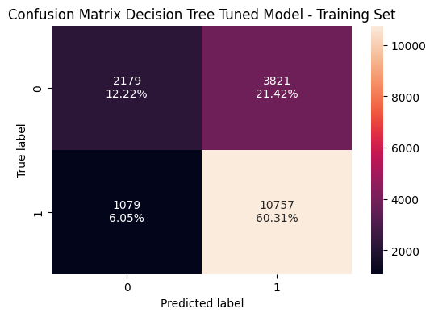

```python
#Checking model performance on training data
confusion_matrix_sklearn(dtree_estimator, X_train, Y_train)
plt.title("Confusion Matrix Decision Tree Tuned Model - Training Set");
```

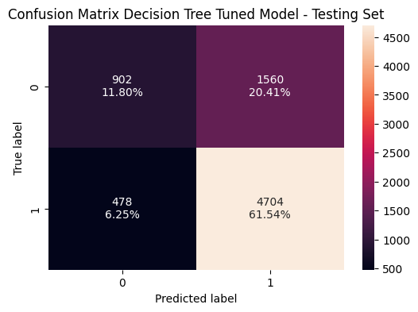

```python
#Checking model performance on testing data
confusion_matrix_sklearn(dtree_estimator, X_test, Y_test)
plt.title("Confusion Matrix Decision Tree Tuned Model - Testing Set");
```

```python
dtree_estimator_model_train_perf=model_performance_classification_sklearn(dtree_estimator, X_train,Y_train)
print("Training performance \n")
dtree_estimator_model_train_perf
```

```
Training performance
```

|  | Accuracy | Recall | Precision | F1 |
| --- | --- | --- | --- | --- |
| 0 | 0.725275 | 0.908837 | 0.737893 | 0.814492 |

```python
dtree_estimator_model_test_perf=model_performance_classification_sklearn(dtree_estimator, X_test, Y_test)
print("Testing performance \n")
dtree_estimator_model_test_perf
```

```
Testing performance
```

|  | Accuracy | Recall | Precision | F1 |
| --- | --- | --- | --- | --- |
| 0 | 0.732601 | 0.90467 | 0.751523 | 0.821016 |

#### Observations

- The Decision Tree model after tuning performs equally well on the training and testing datasets, indicating that the model is not overfit.
- Additionally, this model performs as well as two out of the three boosting models above on the test data.
- Both of these indicate this tuned model is a significant improvements over the base model.

#### Tuning Bagging Classifier

Hyperparameters available for bagging classifier include:

- base_estimator: The base estimator to fit on random subsets of the dataset. If None(default), then the base estimator is a decision tree.
- n_estimators: The number of trees in the forest, default = 100.
- max_features: The number of features to consider when looking for the best split.
- bootstrap: Whether bootstrap samples are used when building trees. If False, the entire dataset is used to build each tree, default=True.
- bootstrap_features: If it is true, then features are drawn with replacement. Default value is False.
- max_samples: If bootstrap is True, then the number of samples to draw from X to train each base estimator. If None (default), then draw N samples, where N is the number of observations in the train data.
- oob_score: Whether to use out-of-bag samples to estimate the generalization accuracy, default=False.

```python
# random search for bagging classifier
parameters = {'max_samples': [0.7,0.8,0.9,1],
              'max_features': [0.7,0.8,0.9,1],
              'n_estimators' : np.arange(50, 100, 10)
             }

#run the randomized search
rand_bag = RandomizedSearchCV(BaggingClassifier(random_state=1,bootstrap=True),
                              parameters, scoring = 'f1', cv = 5, random_state=1)
rand_bag = rand_bag.fit(X_train, Y_train)

# Set the clf to the best combination of parameters
bag_tuned = rand_bag.best_estimator_

# Fit the best algorithm to the data
bag_tuned.fit(X_train, Y_train)
```

```
BaggingClassifier(max_features=0.8, max_samples=0.8, n_estimators=np.int64(70),
                  random_state=1)
```

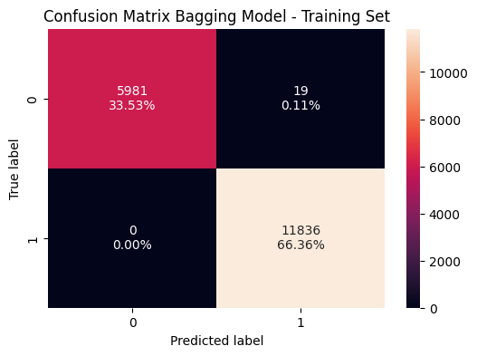

```python
#create a confusion matrix of the classifier's performance on the training data
confusion_matrix_sklearn(bag_tuned, X_train,Y_train)
plt.title("Confusion Matrix Bagging Model - Training Set");
```

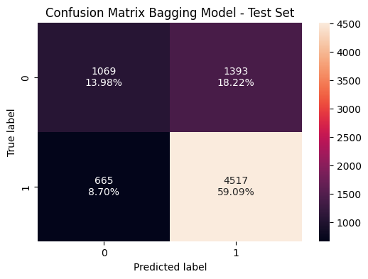

```python
#create a confusion matrix of the classifier's performance on the testing data
confusion_matrix_sklearn(bag_tuned, X_test,Y_test)
plt.title("Confusion Matrix Bagging Model - Test Set");
```

```python
bagging_estimator_model_train_perf=model_performance_classification_sklearn(bag_tuned, X_train,Y_train)
print("Training performance \n")
bagging_estimator_model_train_perf
```

```
Training performance
```

|  | Accuracy | Recall | Precision | F1 |
| --- | --- | --- | --- | --- |
| 0 | 0.998935 | 1.0 | 0.998397 | 0.999198 |

```python
bagging_estimator_model_test_perf=model_performance_classification_sklearn(bag_tuned, X_test, Y_test)
print("Testing performance \n")
bagging_estimator_model_test_perf
```

```
Testing performance
```

|  | Accuracy | Recall | Precision | F1 |
| --- | --- | --- | --- | --- |
| 0 | 0.725798 | 0.866461 | 0.761792 | 0.810762 |

- The Bagging Classifier after tuning performs far less well on the test data than on the training data, indicating that the model is still overfit.
- However, this model does perform better than the base model.